# assignment_2_Pesci

Eugenia Pesci

2023-03-24

```r
library(tidyverse)
library(here)
```

## Import the data

```r
# Import LiTS data
lits_subset <- here("lits_subset.csv") %>%
  read.csv()

# Import Putin's approval ratings data
putins_approval <- here("levada_president_longer.csv") %>%
  read.csv() %>%
  mutate(date = ymd(date))

# Import updated V-Dem data
vdem_upd <- here("vdem_subset_upd.csv") %>%
  read.csv()
```

## Assignment 1

Answer the following questions: 1. What can you say on the relationship between age_pr and household_income based on your scatter plot? Or can you say anything? There are no right or wrong answers, just use your own words about your first impression. 2. Are there extreme values in the variables plotted? Extreme values are simply mean individual observations (here: points) that are far away from the rest of the observations.

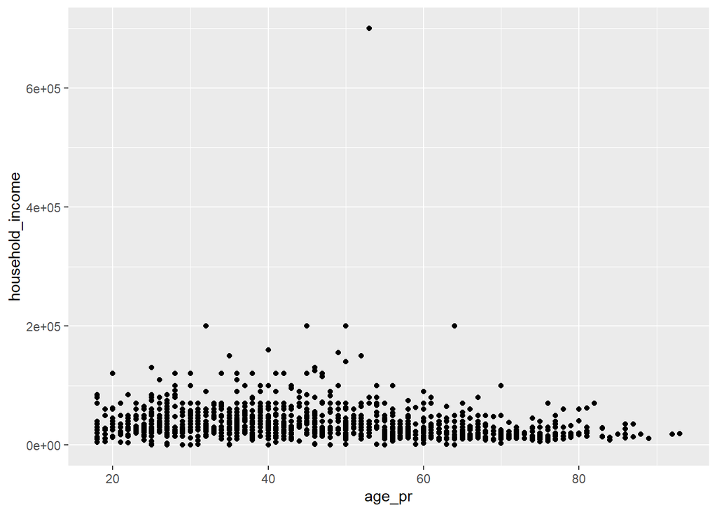

```r
rus_income_and_age <- lits_subset %>%
  filter(country == 'Russia')

ggplot(rus_income_and_age) +
  aes(x = age_pr, y = household_income) +
  geom_point()
```

## Assignment 2

Using the levada_president_longer.csv data, draw a line graph of Vladimir Putin’s approval ratings using ggplot() and geom_line() functions. 🧐 Add the approval variable to your plot. Hint: good way to add categorical variables to ggplot() s (or plots in general) is to put categorical variable as color argument within the aes() function call. Check the gapminder plot example on Theme 2’s lecture slides if you are unsure what I’m talking about.

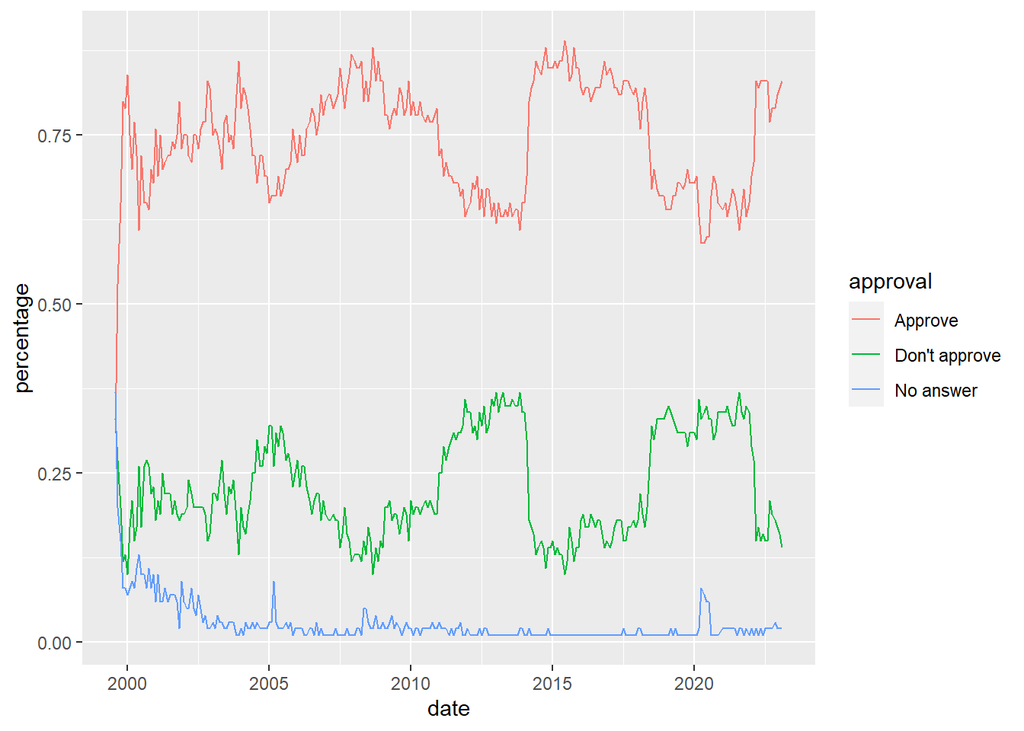

```r
ggplot(putins_approval) +
  aes(x = date, y = percentage, color = approval) +
  geom_line()
```

## Assignment 3

Bar plot with geom_col()

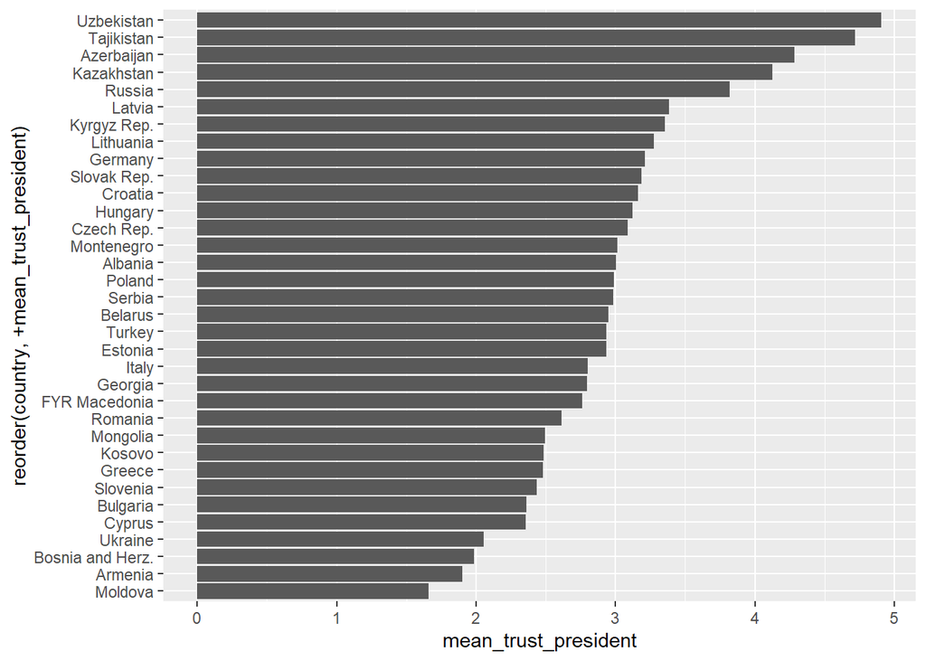

```r
lits_president_trust <- lits_subset %>%
  drop_na(trust_president) %>%
  group_by(country) %>%
  summarise(mean_trust_president = mean(trust_president))

ggplot(lits_president_trust) +
  aes(y = reorder(country, + mean_trust_president),
      x = mean_trust_president) +
      geom_col()
```

## Assignment 4

Histogram with geom_histogram(), and Density plot with geom_density()

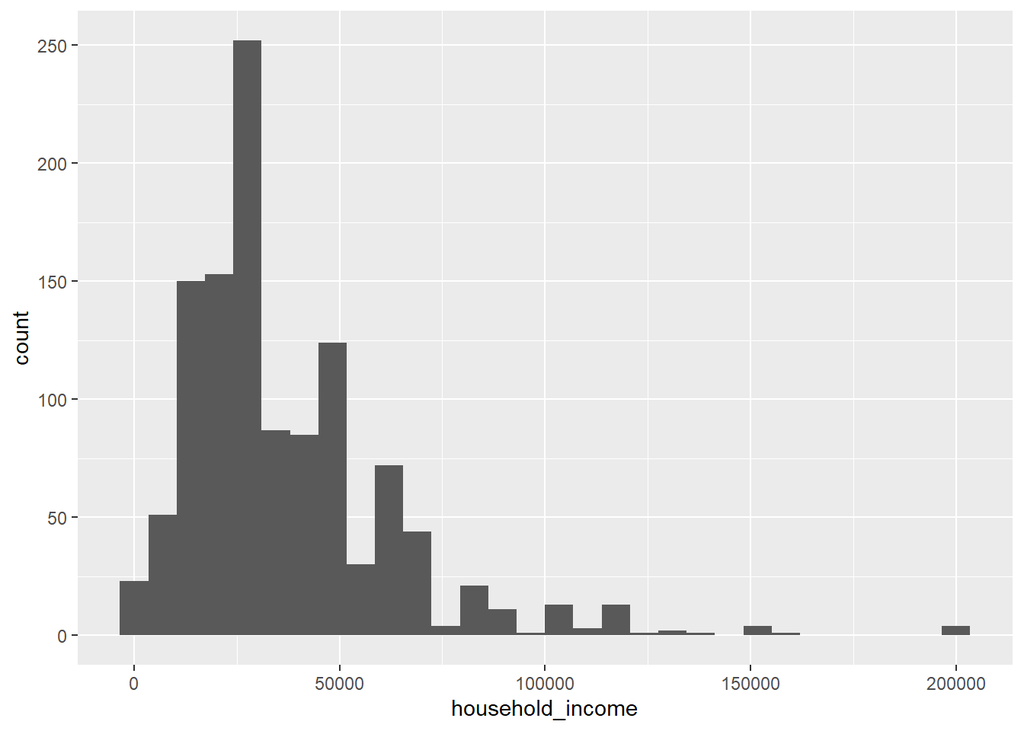

```r
rus_income_and_age <- lits_subset %>%
 filter(country == "Russia") %>%
 filter(household_income < 210000) %>%
 select(country, household_income, age_pr) %>%
 drop_na()
# Histogram of household income
ggplot(rus_income_and_age) +
 aes(x = household_income) +
 geom_histogram()
```

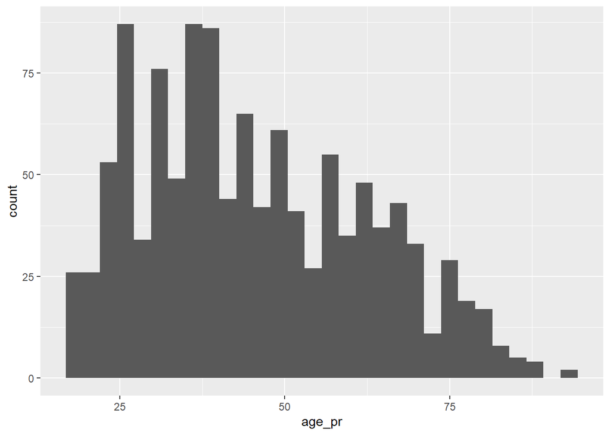

```r
# Histogram of age
ggplot(rus_income_and_age) +
  aes(x = age_pr) +
  geom_histogram()
```

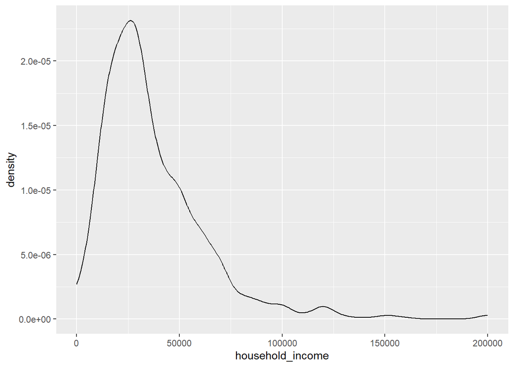

```r
# Density plot of household income: draw below
ggplot(rus_income_and_age) +
  aes(x = household_income) +
  geom_density()
```

## Assignment 5

Boxplot with geom_boxplot()

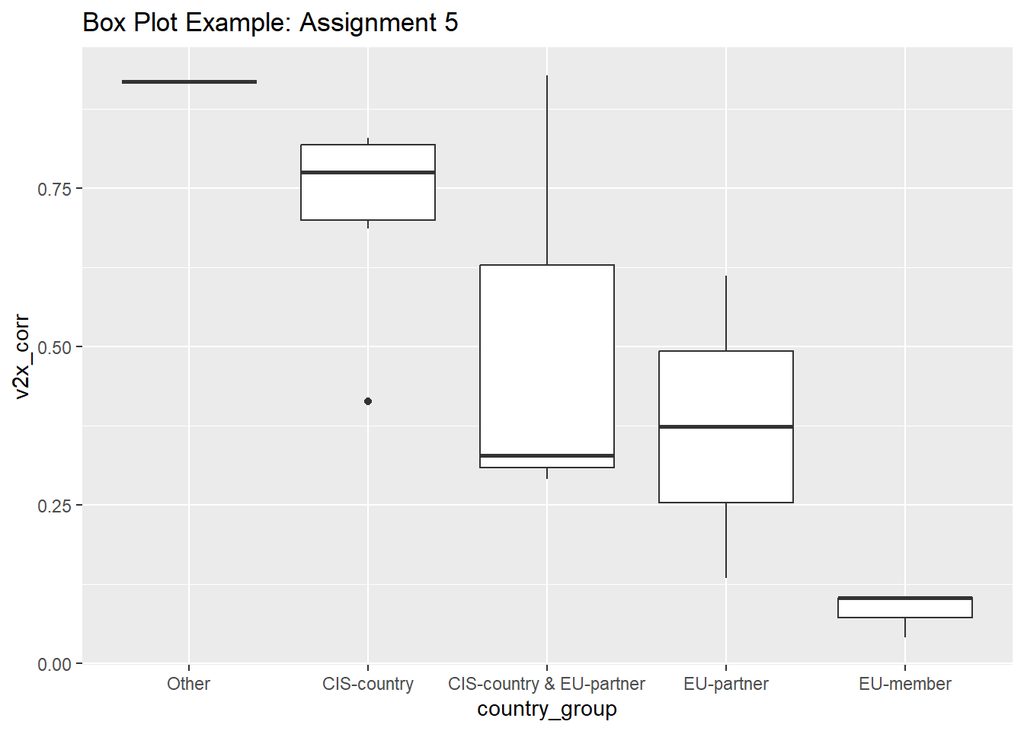

```r
# Subset the data
vdem_boxplot_corruption <- vdem_upd %>%
 filter(year == "2022",
 !is.na(country_group))
ggplot(vdem_boxplot_corruption) +
 aes(x = reorder(country_group, -v2x_corr), y = v2x_corr) +
  geom_boxplot() +
  labs(title = "Box Plot Example: Assignment 5",
       x = "country_group")
```